# Modeling and prediction for movies

## Introduction

As part of the Linear Regression and Modeling course, the final task is to prepare and submit a data analysis project. The data analysis project is involving dataset information from Rotten Tomatoes and IMDB for a random sample of movies.

The task is to identify the attributes that make a movie popular. In the same time to learn new things about movies.

## Setup

### Load packages

The following are the R packages required in this report.

```r
library(ggplot2)
library(dplyr)
library(statsr)
library(stargazer)
library(lmtest)
library(kableExtra)
library(tidyverse)
library(patchwork)
library(lubridate)
library(GGally)
library(car)
```

### Load data

The following dataset is load into R. The dataset are as provided for the purposed of this report.

```r
load("movies.Rdata")
```

## Part 1: Data

The dataset contains *651 rows* and *32 columns* as described below. Each row in the dataset is a movie and each column is a characteristic of a movie.

```r
dim(movies)
```

```
## [1] 651  32
```

The following shows the names of each columns in the dataset.

```r
names(movies)
```

```
##  [1] "title"            "title_type"       "genre"            "runtime"
##  [5] "mpaa_rating"      "studio"           "thtr_rel_year"    "thtr_rel_month"
##  [9] "thtr_rel_day"     "dvd_rel_year"     "dvd_rel_month"    "dvd_rel_day"
## [13] "imdb_rating"      "imdb_num_votes"   "critics_rating"   "critics_score"
## [17] "audience_rating"  "audience_score"   "best_pic_nom"     "best_pic_win"
## [21] "best_actor_win"   "best_actress_win" "best_dir_win"     "top200_box"
## [25] "director"         "actor1"           "actor2"           "actor3"
## [29] "actor4"           "actor5"           "imdb_url"         "rt_url"
```

The dataset contains movies from year 1970 to 2014 as described below.

```r
range(movies$thtr_rel_year)
```

```
## [1] 1970 2014
```

The following shows the nos. of movies per year as in the dataset.

```r
plot_a <- movies %>% group_by(thtr_rel_year) %>% summarise(n())
head(plot_a)
```

```
## # A tibble: 6 x 2
##   thtr_rel_year `n()`
##           <dbl> <int>
## 1          1970     1
## 2          1972     3
## 3          1973     4
## 4          1974     8
## 5          1975     5
## 6          1976     4
```

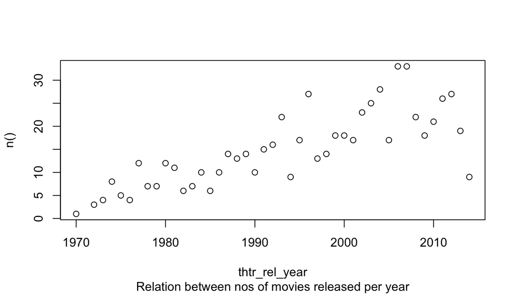

```r
plot(plot_a) %>% title("Relation between nos of movies released per year")
```

The data should allow us to generalize to the population of interest. However, there is no causation can be established because random assignment is not used in this study. In addition, potential biases are associated with non-voting or non_rating because the voting and rating are voluntary on IMDB and Rotten Tomatoes website.

## Part 2: Research question

This data analysis project is to study the attributes that contributes to the popularity of a movie.

The following information in the dataset will be explore in the next section in order to understand the popularity of a movies:-

1. title_type: Type of movie (Documentary, Feature Film, TV Movie)
2. genre: Genre of movie (Action & Adventure, Comedy, Documentary, Drama, Horror, Mystery & Suspense, Other)
3. runtime: Runtime of movie (in minutes)
4. imdb_rating: Rating on IMDB
5. imdb_num_votes: Number of votes on IMDB
6. critics_rating: Categorical variable for critics rating on Rotten Tomatoes (Certified Fresh, Fresh, Rotten)
8. critics_score: Critics score on Rotten Tomatoes
9. audience_rating: Categorical variable for audience rating on Rotten Tomatoes (Spilled, Upright)
10. audience_score: Audience score on Rotten Tomatoes
11. best_pic_win: Whether or not the movie won a best picture Oscar (no, yes)
12. best_actor_win: Whether or not one of the main actors in the movie ever won an Oscar (no, yes) - note that this is not necessarily whether the actor won an Oscar for their role in the given movie
13. best_actress win: Whether or not one of the main actresses in the movie ever won an Oscar (no, yes) - not that this is not necessarily whether the actresses won an Oscar for their role in the given movie
14. best_dir_win: Whether or not the director of the movie ever won an Oscar (no, yes) - not that this is not necessarily whether the director won an Oscar for the given movie

## Part 3: Exploratory data analysis

Based on the dataset summarised the following items:-

1. The **lowest** IMDB rating is **1.9** and the **highest** IMDB rating is **9.0**. The **average** IMDB rating is **6.5**.
2. The **lowest** movie runtime is **39.0 min** and the **highest** movie runtime is **267 min**. The **average** movie runtime is **105.8 min**.
3. The **lowest** critic score is **1.0** and the **highest** critic score is **100.0**. The **average** critic score is **57.69**.
4. The **lowest** audience score is **11.0** and the **highest** audience score is **97.0**. The **average** audience score is **62.36**.
5. There are **7** movies have won the **best picture award**.
6. There are **43** movies have won the **best director award**.

The detail are as follow.

```r
summary(movies %>%
select(title, title_type, genre, runtime, imdb_rating, imdb_num_votes, critics_rating, critics_score, audience_rating, audience_score, best_pic_win, best_dir_win))
```

```
##     title                  title_type                 genre        runtime
##  Length:651         Documentary : 55   Drama             :305   Min.   : 39.0
##  Class :character   Feature Film:591   Comedy            : 87   1st Qu.: 92.0
##  Mode  :character   TV Movie    :  5   Action & Adventure: 65   Median :103.0
##                                        Mystery & Suspense: 59   Mean   :105.8
##                                        Documentary       : 52   3rd Qu.:115.8
##                                        Horror            : 23   Max.   :267.0
##                                        (Other)           : 60   NA's   :1
##   imdb_rating    imdb_num_votes           critics_rating critics_score
##  Min.   :1.900   Min.   :   180   Certified Fresh:135    Min.   :  1.00
##  1st Qu.:5.900   1st Qu.:  4546   Fresh          :209    1st Qu.: 33.00
##  Median :6.600   Median : 15116   Rotten         :307    Median : 61.00
##  Mean   :6.493   Mean   : 57533                          Mean   : 57.69
##  3rd Qu.:7.300   3rd Qu.: 58300                          3rd Qu.: 83.00
##  Max.   :9.000   Max.   :893008                          Max.   :100.00
##
##  audience_rating audience_score  best_pic_win best_dir_win
##  Spilled:275     Min.   :11.00   no :644      no :608
##  Upright:376     1st Qu.:46.00   yes:  7      yes: 43
##                  Median :65.00
##                  Mean   :62.36
##                  3rd Qu.:80.00
##                  Max.   :97.00
##
```

The following plot shows the relations between IMDB rating, movies runtime, critic score and audience score for all the movies.

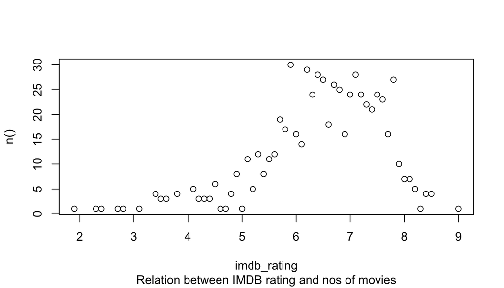

```r
plot_b <- movies %>% group_by(imdb_rating) %>% summarise(n())
plot(plot_b) %>% title("Relation between IMDB rating and nos of movies")
```

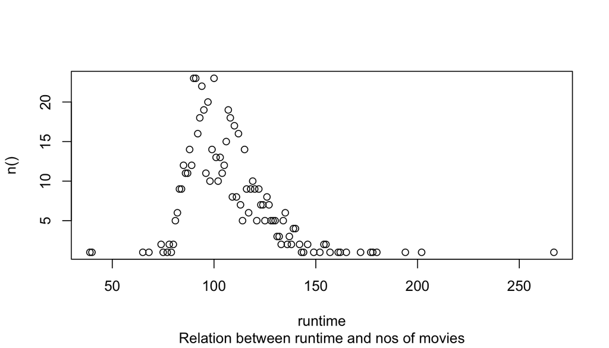

```r
plot_c <- movies %>% group_by(runtime) %>% summarise(n())
plot(plot_c) %>% title("Relation between runtime and nos of movies")
```

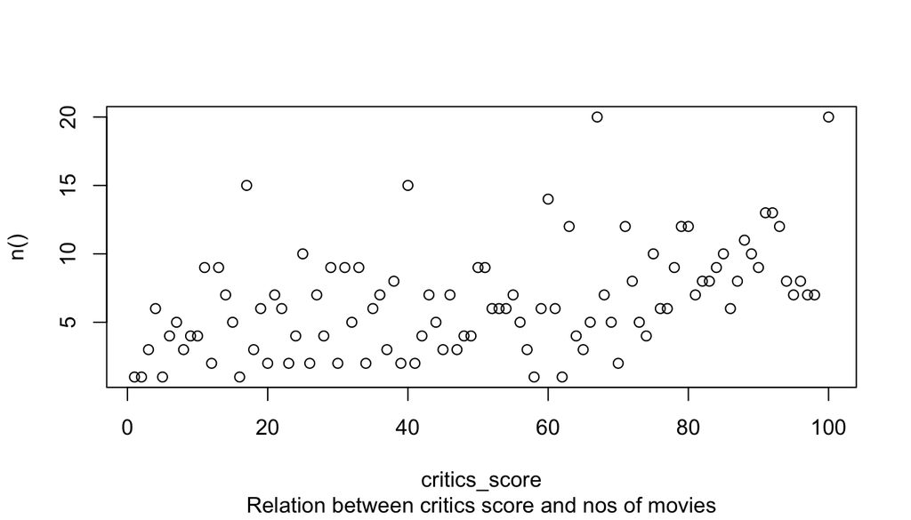

```r
plot_d <- movies %>% group_by(critics_score) %>% summarise(n())
plot(plot_d) %>% title("Relation between critics score and nos of movies")
```

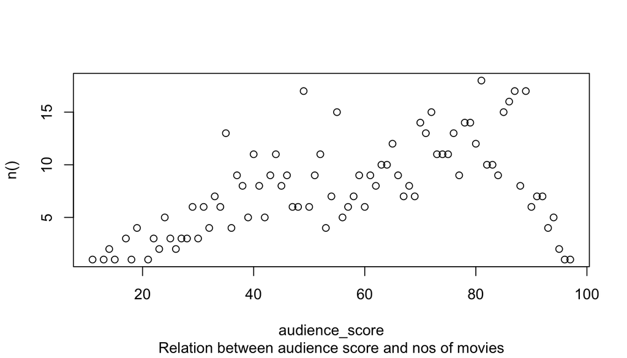

```r
plot_e <- movies %>% group_by(audience_score) %>% summarise(n())
plot(plot_e) %>% title("Relation between audience score and nos of movies")
```

```r
summary(movies %>%
select(title_type, critics_rating, audience_rating, best_pic_win))
```

```
##         title_type          critics_rating audience_rating best_pic_win
##  Documentary : 55   Certified Fresh:135    Spilled:275     no :644
##  Feature Film:591   Fresh          :209    Upright:376     yes:  7
##  TV Movie    :  5   Rotten         :307
```

The following shows the information about the movies.

```r
movies.tb0 <- movies %>%
  select(title:best_dir_win) %>%
  select(-contains("DVD"))
movies.tb0 %>%
  select(c("mpaa_rating","title_type","imdb_rating","imdb_num_votes","critics_rating","audience_rating","runtime")) %>%
  Hmisc::describe()
```

```
## .
##
##  7  Variables      651  Observations
## --------------------------------------------------------------------------------
## mpaa_rating
##        n  missing distinct
##      651        0        6
##
## lowest : G       NC-17   PG      PG-13   R
## highest: NC-17   PG      PG-13   R       Unrated
##
## Value            G   NC-17      PG   PG-13       R Unrated
## Frequency       19       2     118     133     329      50
## Proportion   0.029   0.003   0.181   0.204   0.505   0.077
## --------------------------------------------------------------------------------
## title_type
##        n  missing distinct
##      651        0        3
##
## Value       Documentary Feature Film     TV Movie
## Frequency            55          591            5
## Proportion        0.084        0.908        0.008
## --------------------------------------------------------------------------------
## imdb_rating
##        n  missing distinct     Info     Mean      Gmd      .05      .10
##      651        0       56    0.999    6.493    1.188      4.4      5.1
##      .25      .50      .75      .90      .95
##      5.9      6.6      7.3      7.8      7.9
##
## lowest : 1.9 2.3 2.4 2.7 2.8, highest: 8.2 8.3 8.4 8.5 9.0
## --------------------------------------------------------------------------------
## imdb_num_votes
##        n  missing distinct     Info     Mean      Gmd      .05      .10
##      651        0      644        1    57533    82704     1288     1995
##      .25      .50      .75      .90      .95
##     4546    15116    58300   151934   262774
##
## lowest :    180    183    281    285    318, highest: 753592 756602 797101 806911 893008
## --------------------------------------------------------------------------------
## critics_rating
```

[output cut: 8 more lines]

```
##        n  missing distinct
##      651        0        2
##
## Value      Spilled Upright
## Frequency      275     376
## Proportion   0.422   0.578
## --------------------------------------------------------------------------------
## runtime
##        n  missing distinct     Info     Mean      Gmd      .05      .10
##      650        1       89        1    105.8    20.11    83.45    86.90
##      .25      .50      .75      .90      .95
##    92.00   103.00   115.75   129.00   137.55
##
## lowest :  39  40  65  68  74, highest: 178 180 194 202 267
## --------------------------------------------------------------------------------
```

```r
movies.tb0 %>% sapply(is.na) %>% colSums()
```

```
##            title       title_type            genre          runtime
##                0                0                0                1
##      mpaa_rating           studio    thtr_rel_year   thtr_rel_month
##                0                8                0                0
##     thtr_rel_day      imdb_rating   imdb_num_votes   critics_rating
##                0                0                0                0
##    critics_score  audience_rating   audience_score     best_pic_nom
##                0                0                0                0
##     best_pic_win   best_actor_win best_actress_win     best_dir_win
##                0                0                0                0
```

The following plot shows the movies spread in each quarter with different MPAA ratings the category of the movie.

```r
movies.tb0 <- movies.tb0 %>% filter(!is.na(runtime))
movies.tb1 <- movies.tb0 %>%
  mutate(mpaa_rating = fct_relevel(mpaa_rating,"Unrated","NC-17","R","PG-13","PG","G"),
         thtr_date = make_date(thtr_rel_year,thtr_rel_month,thtr_rel_day),
         thtr_quat = quarter(thtr_date),
         osca_opt  = ifelse(best_pic_nom=="yes"|best_pic_win=="yes"|best_actor_win=="yes"|
                              best_actress_win=="yes"|best_dir_win=="yes",1,0))
temp1 <- movies.tb1 %>%
  group_by(thtr_quat,mpaa_rating) %>%
  summarise(num_quat=n()) %>%
  mutate(label_y = cumsum(num_quat) - 0.5*num_quat)
```

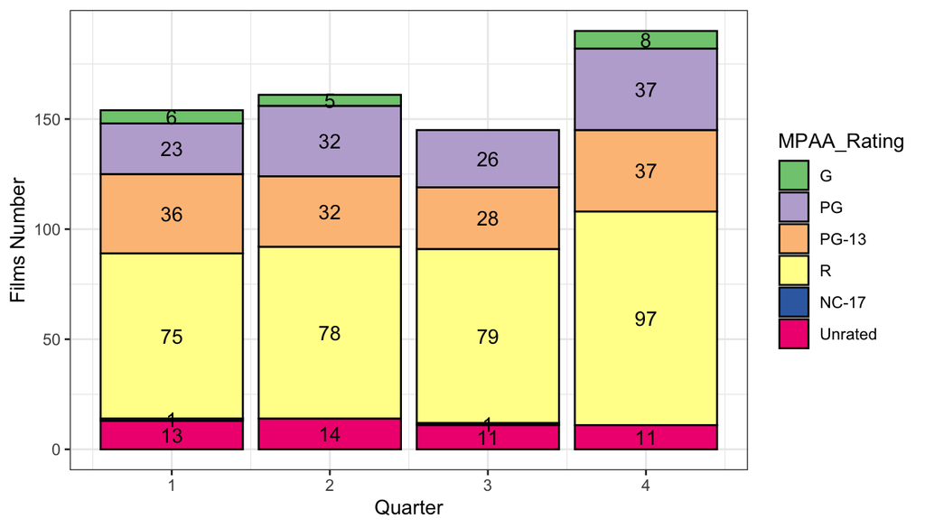

```r
ggplot(temp1,aes(x=thtr_quat,y=num_quat,fill=fct_rev(mpaa_rating)))+
  geom_col(colour="black")+
  labs(fill="MPAA_Rating")+ ylab("Films Number") + xlab("Quarter") +
  geom_text(aes(y=label_y,label=num_quat)) +
  scale_fill_brewer(palette = "Accent") + theme_bw()
```

The following plot shows the number of films of various genres in different MPAA ratings

```r
temp2 <- movies.tb1 %>%
  group_by(mpaa_rating,genre) %>%
  summarise(num_genre=n()) %>%
  ungroup()
```

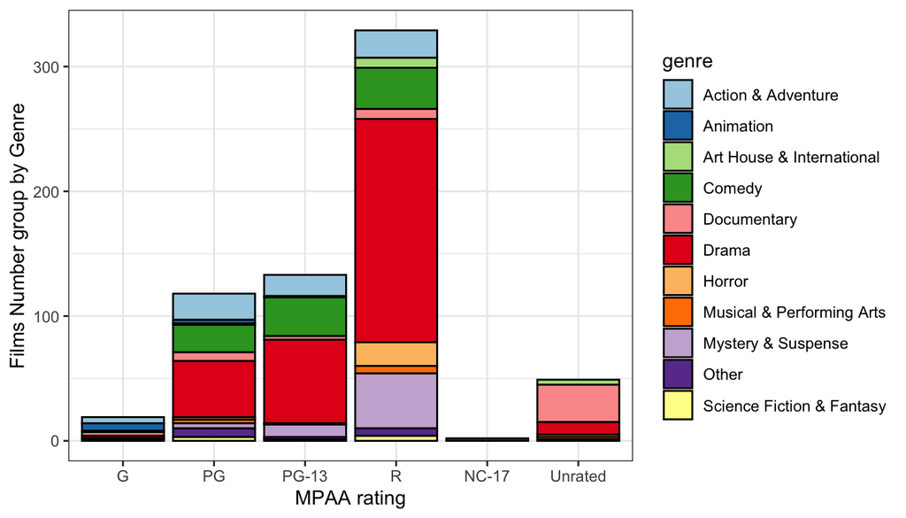

```r
ggplot(temp2,aes(x=fct_rev(mpaa_rating),y=num_genre,fill=genre))+
  geom_col(color="black")+
  ylab("Films Number group by Genre") + xlab("MPAA rating") +
  scale_fill_brewer(palette = "Paired") + theme_bw()
```

The following plot shows the density of movies rating on IMDB.

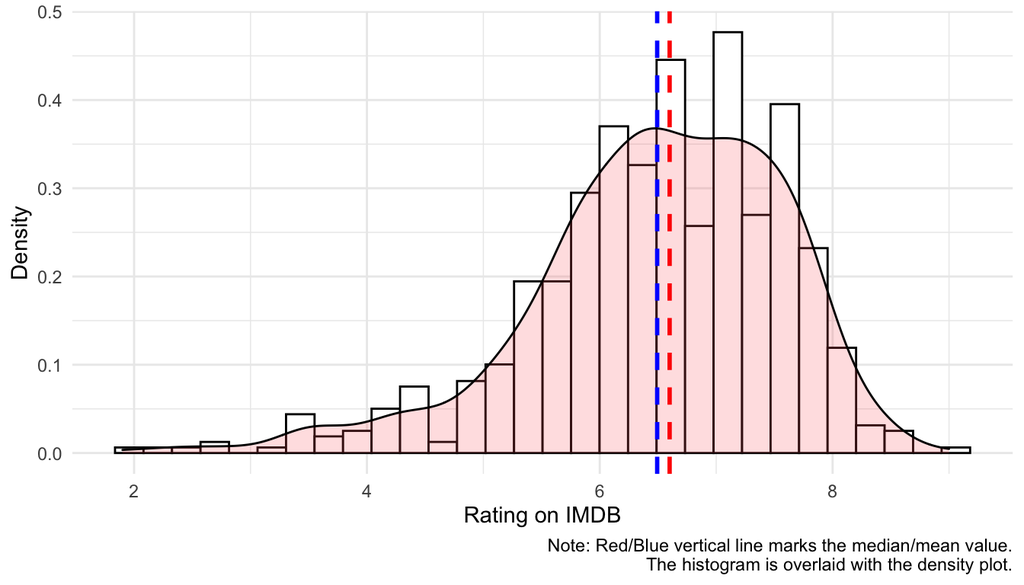

```r
distribution<-function(var){
  ggplot(movies, aes(x=var)) +
  geom_histogram(aes(y=..density..), colour="black", fill="white")+
  geom_density(alpha=.2, fill="#FF6666")+
  geom_vline(aes(xintercept=mean(var)),
             color="blue", linetype="dashed", size=1)+
  geom_vline(aes(xintercept=median(var)),
             color="red", linetype="dashed", size=1)+
  ylab("Density")+
  labs(caption="Note: Red/Blue vertical line marks the median/mean value.
       The histogram is overlaid with the density plot.")+
  theme_minimal()
}
distribution(movies$imdb_rating)+xlab('Rating on IMDB')
```

Thw IMDB rating plots shows a left skewed distribution. For a left skewed distribution, the median will be higher that the mean value of the samples.

The following plot shows the density of movies runtime.

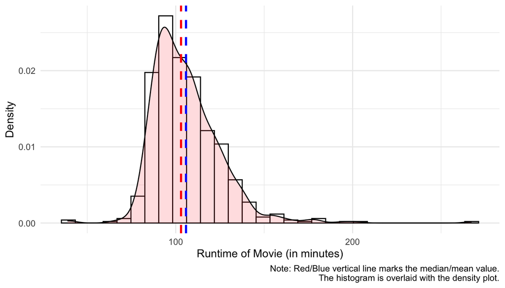

```r
ggplot(movies[!is.na(movies$runtime),], aes(x=runtime)) +
  geom_histogram(aes(y=..density..), colour="black", fill="white")+
  geom_density(alpha=.2, fill="#FF6666")+
  geom_vline(aes(xintercept=mean(runtime)),
             color="blue", linetype="dashed", size=1)+
  geom_vline(aes(xintercept=median(runtime)),
             color="red", linetype="dashed", size=1)+
  xlab('Runtime of Movie (in minutes)')+
  ylab("Density")+
  labs(caption="Note: Red/Blue vertical line marks the median/mean value.
       The histogram is overlaid with the density plot.")+
  theme_minimal()
```

The movies runtime plots shows a right skewed distribution graph. For a right skewed distribution, the mean will be higher than the median value of the samples.

[figure not shown]

```r
distribution(movies$critics_score)+xlab('Critics Score on Rotten Tomatoes')
```

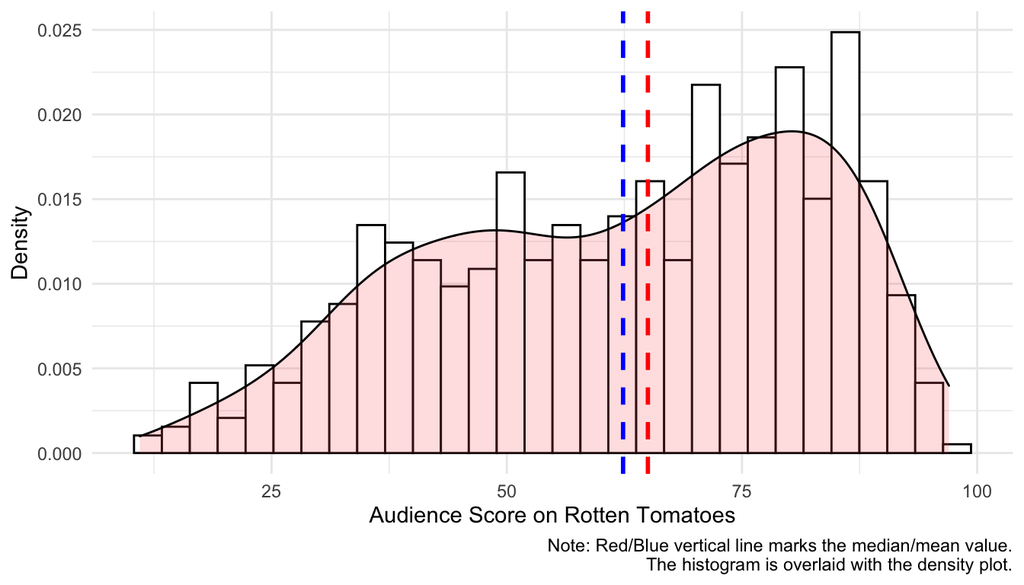

```r
distribution(movies$audience_score)+xlab('Audience Score on Rotten Tomatoes')
```

The following plots shows four predictors that hav ereasonable distributions and they are suitable for the regression analysis. The *imdb_num_votes* was applied log10 in order to get a proper visualization due to the existence of some larhe numbers of votes.

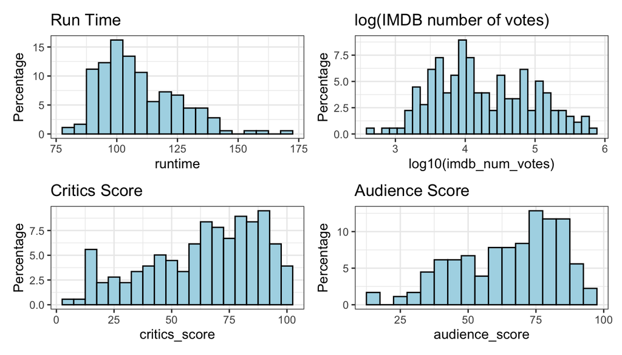

```r
dra_rfs <- movies.tb1 %>%
  filter(genre=="Drama",mpaa_rating=="R")

dra_rfs <- dra_rfs %>%
  select(-genre,-mpaa_rating) %>%
  select(-contains("best_")) %>%
  select(imdb_rating, runtime, imdb_num_votes, critics_score, audience_score,
         osca_opt, thtr_quat, everything())

p1 <- ggplot(dra_rfs, aes(x=runtime)) +
  geom_histogram(aes(y=100*(..count..)/sum(..count..)), color='black', fill='lightblue', binwidth = 5) +
  ylab('Percentage') + ggtitle('Run Time') + theme_bw()

p2 <- ggplot(dra_rfs, aes(x=log10(imdb_num_votes))) +
  geom_histogram(aes(y=100*(..count..)/sum(..count..)), color='black', fill='lightblue') +
  ylab('Percentage') + ggtitle('log(IMDB number of votes)')+ theme_bw()

p3 <- ggplot(dra_rfs, aes(x=critics_score)) +
  geom_histogram(aes(y=100*(..count..)/sum(..count..)), color='black', fill='lightblue', binwidth = 5) +
  ylab('Percentage') + ggtitle('Critics Score')+ theme_bw()

p4 <- ggplot(dra_rfs, aes(x=audience_score)) +
  geom_histogram(aes(y=100*(..count..)/sum(..count..)), color='black', fill='lightblue', binwidth = 5) +
  ylab('Percentage') + ggtitle('Audience Score') + theme_bw()

p1 + p2 + p3 + p4 + plot_layout(ncol = 2)
```

## Part 4: Modeling

We fit a multiple linear regression model with *imdb_rating* as the response variable, and *title_type*, *runtime*, *critics_rating*, *critics_score*, *audience_rating*, *audience_score* and *best_pic_win* as predictors. Regression result is shown in the first column in the following table.

The coefficient of *best_pic_win* is not significant, therefore we exclude this variable based on **backwards elimination (p-value)**. The new regression result is in the second column. The coefficients of the remaining variables as well as the model’s adjusted R-squared do not change too much.

```r
OLS1<-lm(imdb_rating ~ title_type+runtime+critics_rating+
          critics_score+audience_rating+audience_score+best_pic_win,data = movies)
OLS2<-lm(imdb_rating ~ title_type+runtime+critics_rating+
          critics_score+audience_rating+audience_score,data = movies)
stargazer(OLS1,OLS2,type='text')
```

```
##
## ========================================================================
##                                       Dependent variable:
##                        -------------------------------------------------
##                                           imdb_rating
##                                  (1)                      (2)
## ------------------------------------------------------------------------
## title_typeFeature Film         -0.166**                 -0.165**
##                                (0.073)                  (0.072)
##
## title_typeTV Movie             -0.369*                  -0.368*
##                                (0.219)                  (0.219)
##
## runtime                        0.006***                 0.006***
##                                (0.001)                  (0.001)
##
## critics_ratingFresh             0.028                    0.024
##                                (0.054)                  (0.054)
##
## critics_ratingRotten           0.273***                 0.271***
##                                (0.090)                  (0.090)
##
## critics_score                  0.015***                 0.015***
##                                (0.002)                  (0.002)
##
## audience_ratingUpright        -0.366***                -0.367***
##                                (0.074)                  (0.074)
##
## audience_score                 0.041***                 0.041***
##                                (0.002)                  (0.002)
##
## best_pic_winyes                 0.071
##                                (0.183)
##
## Constant                       2.668***                 2.663***
##                                (0.182)                  (0.181)
##
## ------------------------------------------------------------------------
## Observations                     650                      650
## R2                              0.819                    0.819
## Adjusted R2                     0.817                    0.817
## Residual Std. Error        0.464 (df = 640)         0.464 (df = 641)
## F Statistic            322.669*** (df = 9; 640) 363.465*** (df = 8; 641)
## ========================================================================
## Note:                                        *p<0.1; **p<0.05; ***p<0.01
```

### Normally distributed error terms

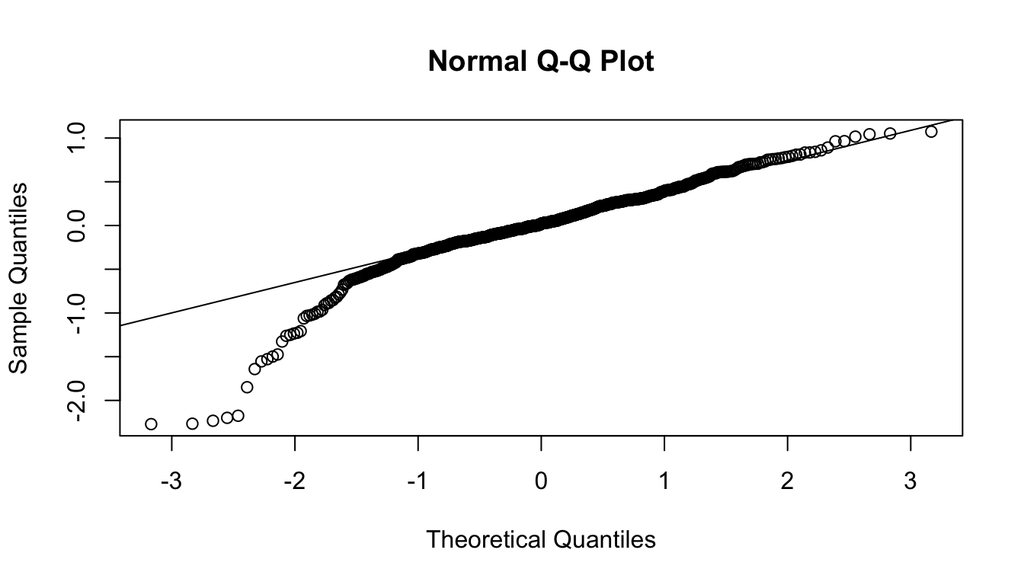

```r
qqnorm(OLS2$residuals)
qqline(OLS2$residuals)
```

### Homoskedasticity

A particularly small p-value as the result of the `Breush-Pagan test` implies that the null hypothesis of homoskedasiticity is rejected. There is, indeed, heteroskedasticity in our model.

```r
lmtest::bptest(OLS2)
```

```
##
##  studentized Breusch-Pagan test
##
## data:  OLS2
## BP = 92.225, df = 8, p-value < 2.2e-16
```

### No autocorrelation

Finally, a large p-value of the `Durbin-Watson test` indicates that there is no autocorrelation.

```r
lmtest::dwtest(OLS2)
```

```
##
##  Durbin-Watson test
##
## data:  OLS2
## DW = 1.9483, p-value = 0.2551
## alternative hypothesis: true autocorrelation is greater than 0
```

Therefore, the interpretation coefficient of the categorical variables and the numeric variables are as follow:-

## Part 5: Prediction

Finally, in this section we will pick three (3) movies, from the Rotten Tomatoes to make prediction of its rating in IMDB. The following movies is selected with the Rotten Tomatoes predictions respectively:-

```r
new_movie<-data.frame(title_type="Feature Film", runtime=111, critics_rating="Certified Fresh",critics_score=61, audience_rating="Spilled",audience_score=52)
predicted<-predict(OLS2,new_movie)
interval<-predict(OLS2,new_movie,interval = "prediction", level = 0.95)
print(paste("The predicted IMDB rating for Project Power is", predicted))
```

```
## [1] "The predicted IMDB rating for Project Power is 6.2064688523883"
```

```r
print(paste("The lower bound of the 95% prediction interval is",interval[2]))
```

```
## [1] "The lower bound of the 95% prediction interval is 5.28689402134422"
```

```r
print(paste("The upper bound of the 95% prediction interval is",interval[3]))
```

```
## [1] "The upper bound of the 95% prediction interval is 7.12604368343237"
```

```r
new_movie<-data.frame(title_type="Feature Film", runtime=56, critics_rating="Certified Fresh",critics_score=100, audience_rating="Spilled",audience_score=76)
predicted<-predict(OLS2,new_movie)
interval<-predict(OLS2,new_movie,interval = "prediction", level = 0.95)
print(paste("The predicted IMDB rating for Host is", predicted))
```

```
## [1] "The predicted IMDB rating for Host is 7.46297857152892"
```

```r
print(paste("The lower bound of the 95% prediction interval is",interval[2]))
```

```
## [1] "The lower bound of the 95% prediction interval is 6.53150151007193"
```

```r
print(paste("The upper bound of the 95% prediction interval is",interval[3]))
```

```
## [1] "The upper bound of the 95% prediction interval is 8.3944556329859"
```

```r
new_movie<-data.frame(title_type="Feature Film", runtime=87, critics_rating="Certified Fresh",critics_score=64, audience_rating="Spilled",audience_score=67)
predicted<-predict(OLS2,new_movie)
interval<-predict(OLS2,new_movie,interval = "prediction", level = 0.95)
print(paste("The predicted IMDB rating for Time Trap is", predicted))
```

```
## [1] "The predicted IMDB rating for Time Trap is 6.73348834046806"
```

```r
print(paste("The lower bound of the 95% prediction interval is",interval[2]))
```

```
## [1] "The lower bound of the 95% prediction interval is 5.81002953105082"
```

```r
print(paste("The upper bound of the 95% prediction interval is",interval[3]))
```

```
## [1] "The upper bound of the 95% prediction interval is 7.6569471498853"
```